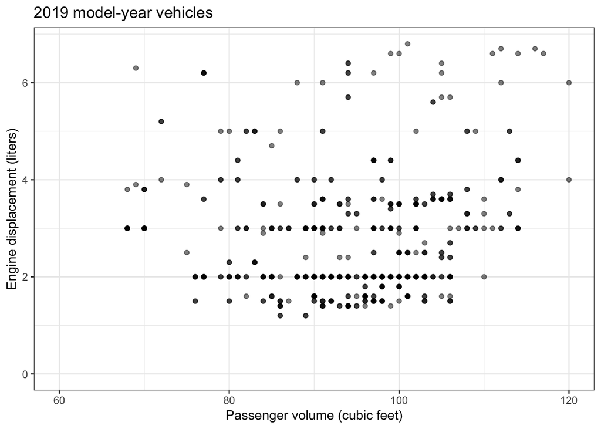

1. Divide the horizontal axis into, strata: <70, 70 to 80, 80 to 90, and so on.
   1. What is a prediction interval on displacement for the 70 to 80 category?
   2. What is a prediction interval on displacement for the 100 to 110 category?

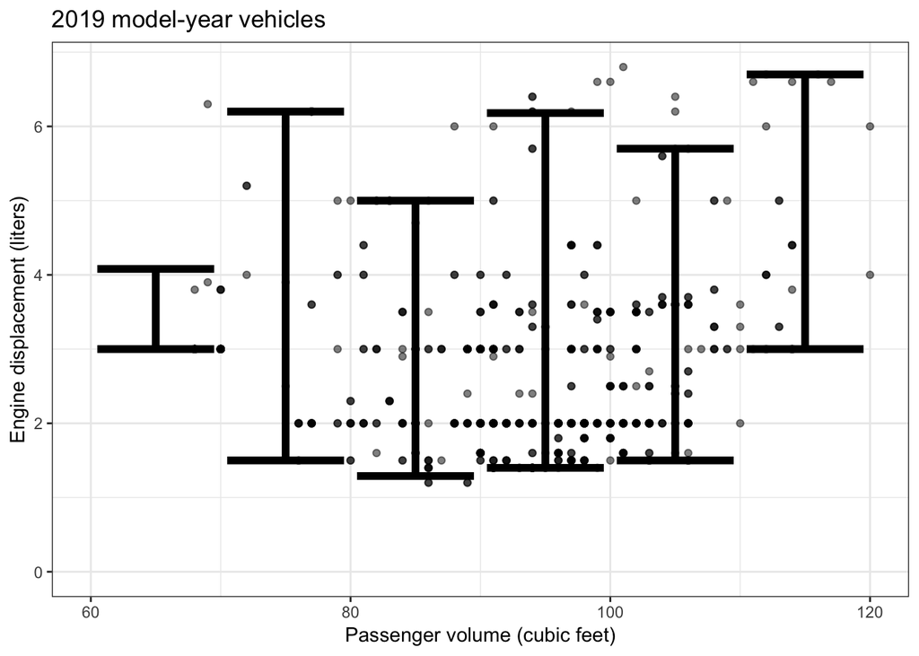

2. Comparing the 70 to 80 and the 100 to 110 cubic feet strata:
   1. how does the engine displacement vary? -A- The prediction intervals are practically identical.
   2. Is there a strong relationship between passenger volume and engine displacement? -A- Since the prediction intervals don’t vary, passenger volume doesn’t seem to be related to displacement.

[figure not shown]

3. Consider the vehicles at the extremes of passenger volume, either very small (< 70) or very large (> 110).
   1. Are these extreme vehicles systematically different in displacement than the large majority of vehicles with passenger volumes between 70 and 110 cubic feet? -A- Yes. Both very small and very large passenger-volume vehicles tend to have higher displacements than the vehicles in the middle.
   2. Are the very large and very small vehicles similar or different from each other in terms of displacement? Give a common-sense explanation for the pattern. -A- Both the very small and the very large passenger-volume vehicles are built for special purposes. The very small vehicles are sports cars, which demand a high engine power and therefore high displacement. The very large vehicles are meant to carry large cargos or tow large loads. This also demands relatively high engine power.